# Eletronic Scooter Analysis

## Project Objective

1. Describe the operations of these two mobility companies.
2. Please estimate the number of scooters company b operates in this geography? Simpler mechanisms of estimation are preferred.

## Contents

1. Environment setting
2. Data Preprocessing
3. Data Visualization - Mobility(Scooter) Usage Overview
4. Feature Generation
5. Modeling (Estimate company B's the number of scooters)
6. Summary

## 0. Environment setting and load data

```python
# import library
import os
import pandas as pd
import numpy as np
import matplotlib.pyplot as plt
import seaborn as sns
import matplotlib.dates as md
```

```python
# load data set
directory = "./data_exercise/"
all_files = os.listdir(directory)
all_files=[x for x in all_files if x.find("csv")>=0]
# split company a and b files
a_files = sorted([x for x in all_files if x.find("company_a")>=0])
b_files = sorted([x for x in all_files if x.find("company_b")>=0])
```

```python
# load each company's files
df_company_a = pd.concat(map(pd.read_csv, [directory+x for x in a_files]), ignore_index=True)
df_company_b = pd.concat(map(pd.read_csv, [directory+x for x in b_files]), ignore_index=True)
print("Total row counts of company a data: ",len(df_company_a))
print("Total row counts of company b data: ",len(df_company_b))
```

```
Total row counts of company a data:  57365
Total row counts of company b data:  10578
```

```python
# check null values
df_company_a.isnull().sum()
```

```
TripID            0
ScooterID         0
StartTime         0
EndTime           0
StartLatitude     0
StartLongitude    0
EndLatitude       1
EndLongitude      1
TripDistance      0
dtype: int64
```

```python
# drop null value
df_company_a.dropna(inplace=True)
```

```python
# check column data type
df_company_a.dtypes
```

```
TripID             object
ScooterID          object
StartTime          object
EndTime            object
StartLatitude     float64
StartLongitude    float64
EndLatitude       float64
EndLongitude      float64
TripDistance      float64
dtype: object
```

```python
# check company a data
df_company_a.head(3)
```

|  | TripID | ScooterID | StartTime | EndTime | StartLatitude | StartLongitude | EndLatitude | EndLongitude | TripDistance |
| --- | --- | --- | --- | --- | --- | --- | --- | --- | --- |
| 0 | 0e56a534-66f4-448b-8eaa-beab76509955 | 5bc901d7-b714-4c57-a614-3d7193da825a | 8/9/18 10:24 | 8/9/18 10:26 | 38.25 | -85.76 | 38.25 | -85.76 | 0.04 |
| 1 | d9280fb0-8135-4750-9c71-c610789ba005 | 3d1905ec-85be-4773-9fe2-34421073363f | 8/9/18 10:26 | 8/9/18 10:56 | 38.25 | -85.74 | 38.26 | -85.77 | 1.98 |
| 2 | 48fa27f3-3b19-4f0e-8665-ee0b188445fd | 5bc901d7-b714-4c57-a614-3d7193da825a | 8/9/18 10:26 | 8/9/18 10:35 | 38.25 | -85.76 | 38.25 | -85.76 | 0.06 |

```python
df_company_a.describe().T
```

|  | count | mean | std | min | 25% | 50% | 75% | max |
| --- | --- | --- | --- | --- | --- | --- | --- | --- |
| StartLatitude | 57364.0 | 38.243420 | 0.016140 | 38.10 | 38.23 | 38.25 | 38.26 | 38.34 |
| StartLongitude | 57364.0 | -85.745516 | 0.020405 | -85.90 | -85.76 | -85.75 | -85.74 | -85.49 |
| EndLatitude | 57364.0 | 38.241914 | 0.172975 | 0.00 | 38.23 | 38.25 | 38.26 | 41.30 |
| EndLongitude | 57364.0 | -85.745865 | 0.433992 | -122.42 | -85.76 | -85.75 | -85.74 | 0.00 |
| TripDistance | 57364.0 | 149.127263 | 13521.755641 | -10344.41 | 0.29 | 0.75 | 1.74 | 1334377.66 |

```python
print("The total number of trips by company-a: ",len(df_company_a.TripID.unique()))
print("The total number of scooter by company-a: ",len(df_company_a.ScooterID.unique()))
```

```
The total number of trips by company-a:  57364
The total number of scooter by company-a:  858
```

- Company A operates 858 scooters during this period.

```python
# check column data type
df_company_b.dtypes
```

```
trip_id              int64
start_time          object
completed_time      object
distance_meters      int64
start_latitude     float64
start_longitude    float64
end_latitude       float64
end_longitude      float64
dtype: object
```

```python
# convert data type of trip_id as object
df_company_b.trip_id = df_company_b.trip_id.astype('object')
```

```python
# check company b data
df_company_b.head(3)
```

|  | trip_id | start_time | completed_time | distance_meters | start_latitude | start_longitude | end_latitude | end_longitude |
| --- | --- | --- | --- | --- | --- | --- | --- | --- |
| 0 | 26559444 | 2018-12-02T12:41:26.000+00:00 | 2018-12-02T12:45:40.000+00:00 | 382 | 38.23 | -85.75 | 38.23 | -85.76 |
| 1 | 26559031 | 2018-12-02T12:39:24.000+00:00 | 2018-12-02T12:41:49.000+00:00 | 109 | 38.26 | -85.75 | 38.26 | -85.76 |
| 2 | 26552748 | 2018-12-02T12:08:07.000+00:00 | 2018-12-02T12:18:29.000+00:00 | 2547 | 38.21 | -85.75 | 38.23 | -85.75 |

```python
# convert meter distance to km
df_company_b['distance_kms']=df_company_b['distance_meters']/1000
df_company_b.drop(columns='distance_meters',inplace=True)
# rename columns for dataset of company-b
df_company_b.rename(columns={"trip_id":"TripID","start_time":"StartTime","completed_time":"EndTime","distance_kms":"TripDistance",\
                                "start_latitude":"StartLatitude","start_longitude":"StartLongitude","end_latitude":"EndLatitude","end_longitude":"EndLongitude"}, inplace=True)
```

```python
# show company-b data's statistics
df_company_b.describe().T
```

|  | count | mean | std | min | 25% | 50% | 75% | max |
| --- | --- | --- | --- | --- | --- | --- | --- | --- |
| StartLatitude | 10578.0 | 38.233344 | 0.018315 | 38.09 | 38.220 | 38.230 | 38.250 | 38.32 |
| StartLongitude | 10578.0 | -85.753961 | 0.014404 | -85.81 | -85.760 | -85.760 | -85.750 | -85.56 |
| EndLatitude | 10578.0 | 38.232768 | 0.286526 | 19.42 | 38.220 | 38.230 | 38.250 | 48.86 |
| EndLongitude | 10578.0 | -85.738549 | 1.587107 | -121.89 | -85.760 | -85.760 | -85.750 | 2.36 |
| TripDistance | 10578.0 | 1.486693 | 2.203422 | 0.00 | 0.479 | 0.913 | 1.754 | 100.00 |

## 1. Data Preprocessing

```python
def weekday(x):
    # 0~4 : weekday
    if int(x)<5:
        return 1
    # 5,6 : weekend
    else:
        return 0

def date_processing(df):
    # convert time data's data type
    df.StartTime = pd.to_datetime(df.StartTime)
    df.EndTime = pd.to_datetime(df.EndTime)
    # extract hour, minute, day of week, day, month, year from start time
    df['StartTime_hour'] = df['StartTime'].dt.hour
    df['StartTime_dayofweek'] = df['StartTime'].dt.dayofweek
    df['StartTime_weekday']=df['StartTime_dayofweek'].apply(lambda x:weekday(x))
    df['StartTime_day'] = df['StartTime'].dt.day
    # df['StartTime_week'] = df['StartTime'].dt.isocalendar().week
    df['StartTime_month'] = df['StartTime'].dt.month
    df['StartTime_year'] = df['StartTime'].dt.year
    df['StartDate']=df['StartTime'].dt.strftime('%Y-%m-%d')
    df['EndDate']=df['EndTime'].dt.strftime('%Y-%m-%d')
    # calculate travel time in minute
    df['TravelTime']\
    =np.round((df['EndTime']-df['StartTime']).apply(lambda x:x.total_seconds()/60),2)
    return df
```

```python
df_company_a_modi = date_processing(df_company_a)
df_company_a_modi.head(3)
```

|  | TripID | ScooterID | StartTime | EndTime | StartLatitude | StartLongitude | EndLatitude | EndLongitude | TripDistance | StartTime_hour | StartTime_dayofweek | StartTime_weekday | StartTime_day | StartTime_month | StartTime_year | StartDate | EndDate | TravelTime |
| --- | --- | --- | --- | --- | --- | --- | --- | --- | --- | --- | --- | --- | --- | --- | --- | --- | --- | --- |
| 0 | 0e56a534-66f4-448b-8eaa-beab76509955 | 5bc901d7-b714-4c57-a614-3d7193da825a | 2018-08-09 10:24:00 | 2018-08-09 10:26:00 | 38.25 | -85.76 | 38.25 | -85.76 | 0.04 | 10 | 3 | 1 | 9 | 8 | 2018 | 2018-08-09 | 2018-08-09 | 2.0 |
| 1 | d9280fb0-8135-4750-9c71-c610789ba005 | 3d1905ec-85be-4773-9fe2-34421073363f | 2018-08-09 10:26:00 | 2018-08-09 10:56:00 | 38.25 | -85.74 | 38.26 | -85.77 | 1.98 | 10 | 3 | 1 | 9 | 8 | 2018 | 2018-08-09 | 2018-08-09 | 30.0 |
| 2 | 48fa27f3-3b19-4f0e-8665-ee0b188445fd | 5bc901d7-b714-4c57-a614-3d7193da825a | 2018-08-09 10:26:00 | 2018-08-09 10:35:00 | 38.25 | -85.76 | 38.25 | -85.76 | 0.06 | 10 | 3 | 1 | 9 | 8 | 2018 | 2018-08-09 | 2018-08-09 | 9.0 |

```python
df_company_b_modi = date_processing(df_company_b)
df_company_b_modi.head(3)
```

|  | TripID | StartTime | EndTime | StartLatitude | StartLongitude | EndLatitude | EndLongitude | TripDistance | StartTime_hour | StartTime_dayofweek | StartTime_weekday | StartTime_day | StartTime_month | StartTime_year | StartDate | EndDate | TravelTime |
| --- | --- | --- | --- | --- | --- | --- | --- | --- | --- | --- | --- | --- | --- | --- | --- | --- | --- |
| 0 | 26559444 | 2018-12-02 12:41:26+00:00 | 2018-12-02 12:45:40+00:00 | 38.23 | -85.75 | 38.23 | -85.76 | 0.382 | 12 | 6 | 0 | 2 | 12 | 2018 | 2018-12-02 | 2018-12-02 | 4.23 |
| 1 | 26559031 | 2018-12-02 12:39:24+00:00 | 2018-12-02 12:41:49+00:00 | 38.26 | -85.75 | 38.26 | -85.76 | 0.109 | 12 | 6 | 0 | 2 | 12 | 2018 | 2018-12-02 | 2018-12-02 | 2.42 |
| 2 | 26552748 | 2018-12-02 12:08:07+00:00 | 2018-12-02 12:18:29+00:00 | 38.21 | -85.75 | 38.23 | -85.75 | 2.547 | 12 | 6 | 0 | 2 | 12 | 2018 | 2018-12-02 | 2018-12-02 | 10.37 |

### Trip distance

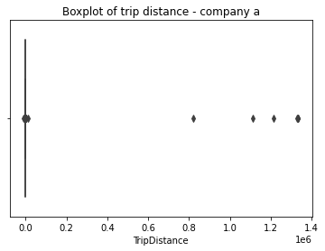

```python
# show Trip distance boxplot
sns.boxplot(x=df_company_a_modi['TripDistance'])
plt.title("Boxplot of trip distance - company a")
plt.show()
```

- Before remove outliers by using IQR method, remove only trip distance is over 500000 km

```python
print("The number of data point which as over 500,000 km: ",sum(df_company_a_modi['TripDistance']>500000))
```

```
The number of data point which as over 500,000 km:  7
```

Remove outliers: over 500,000km trip distance data points

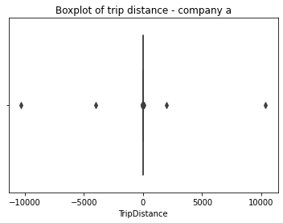

```python
df_company_a_modi2= df_company_a_modi[df_company_a_modi.TripDistance<500000]
# show Trip distance boxplot
sns.boxplot(x=df_company_a_modi2['TripDistance'])
plt.title("Boxplot of trip distance - company a")
plt.show()
```

```python
condition = (df_company_a_modi2['TripDistance']>1000)|(df_company_a_modi2['TripDistance']<-1000)
print("The number of data point where its distance shows less than -1000 or more than 1000km  : ",sum(condition))
df_company_a_modi3= df_company_a_modi2[~condition]
```

```
The number of data point where its distance shows less than -1000 or more than 1000km  :  4
```

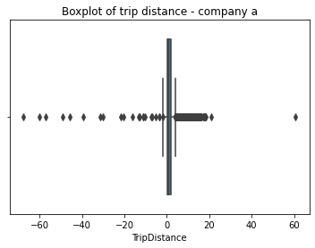

```python
# show Trip distance boxplot
sns.boxplot(x=df_company_a_modi3['TripDistance'])
plt.title("Boxplot of trip distance - company a")
plt.show()
```

```python
print("The number of data points which has distance less than 0: ",sum(df_company_a_modi3['TripDistance']<0))
```

```
The number of data points which has distance less than 0:  66
```

There are 66 data points which have negative distance value (In general, distance is always equal or more than 0).  
Later, we could investigate the trip distance data generation process but now we remove negative value of distance data points.

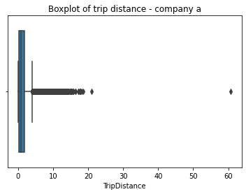

```python
# remove negative distance data
df_company_a_modi4 = df_company_a_modi3[~(df_company_a_modi3['TripDistance']<0)]
# show Trip distance boxplot
sns.boxplot(x=df_company_a_modi4['TripDistance'])
plt.title("Boxplot of trip distance - company a")
plt.show()
```

### Travel Time (generated metric, endTime-startTime)

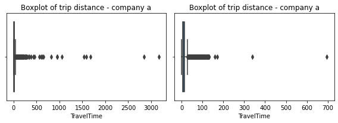

```python
# show Trip distance boxplot
plt.figure(figsize=(8,3))
plt.subplot(1,2,1)
sns.boxplot(x=df_company_a_modi4['TravelTime'])
plt.title("Boxplot of trip distance - company a")
plt.subplot(1,2,2)
sns.boxplot(x=df_company_b_modi['TravelTime'])
plt.title("Boxplot of trip distance - company a")
plt.tight_layout()
plt.show()
```

```python
print("The number of observation which travels more than 12 hours(=720mins): ", sum(df_company_a_modi4.TravelTime>720))
print("The number of observation which travels more than 12 hours(=720mins): ", sum(df_company_b_modi.TravelTime>720))
```

```
The number of observation which travels more than 12 hours(=720mins):  9
The number of observation which travels more than 12 hours(=720mins):  0
```

Let's keep data points which travel less than 12 hours

```python
df_company_a_modi5 = df_company_a_modi4[df_company_a_modi4.TravelTime<=720]
```

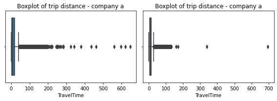

```python
# show Trip distance boxplot
plt.figure(figsize=(8,3))
plt.subplot(1,2,1)
sns.boxplot(x=df_company_a_modi5['TravelTime'])
plt.title("Boxplot of trip distance - company a")
plt.subplot(1,2,2)
sns.boxplot(x=df_company_b_modi['TravelTime'])
plt.title("Boxplot of trip distance - company a")
plt.tight_layout()
plt.show()
```

```python
# compare statistics between two companies
df_company_a_modi5.describe().T
```

|  | count | mean | std | min | 25% | 50% | 75% | max |
| --- | --- | --- | --- | --- | --- | --- | --- | --- |
| StartLatitude | 57278.0 | 38.243421 | 0.016143 | 38.10 | 38.23 | 38.25 | 38.26 | 38.34 |
| StartLongitude | 57278.0 | -85.745528 | 0.020397 | -85.90 | -85.76 | -85.75 | -85.74 | -85.49 |
| EndLatitude | 57278.0 | 38.241914 | 0.173103 | 0.00 | 38.23 | 38.25 | 38.26 | 41.30 |
| EndLongitude | 57278.0 | -85.745877 | 0.434317 | -122.42 | -85.76 | -85.75 | -85.74 | 0.00 |
| TripDistance | 57278.0 | 1.371714 | 1.780939 | 0.00 | 0.29 | 0.75 | 1.74 | 60.75 |
| StartTime_hour | 57278.0 | 14.499005 | 3.357008 | 4.00 | 12.00 | 15.00 | 17.00 | 21.00 |
| StartTime_dayofweek | 57278.0 | 3.240127 | 1.973192 | 0.00 | 2.00 | 3.00 | 5.00 | 6.00 |
| StartTime_weekday | 57278.0 | 0.668302 | 0.470827 | 0.00 | 0.00 | 1.00 | 1.00 | 1.00 |
| StartTime_day | 57278.0 | 15.525228 | 8.649070 | 1.00 | 8.00 | 15.00 | 23.00 | 31.00 |
| StartTime_month | 57278.0 | 10.072750 | 1.247081 | 8.00 | 9.00 | 10.00 | 11.00 | 12.00 |
| StartTime_year | 57278.0 | 2018.000000 | 0.000000 | 2018.00 | 2018.00 | 2018.00 | 2018.00 | 2018.00 |
| TravelTime | 57278.0 | 15.683142 | 20.414235 | 0.00 | 4.00 | 9.00 | 19.00 | 647.00 |

```python
df_company_b_modi.describe().T
```

|  | count | mean | std | min | 25% | 50% | 75% | max |
| --- | --- | --- | --- | --- | --- | --- | --- | --- |
| StartLatitude | 10578.0 | 38.233344 | 0.018315 | 38.09 | 38.220 | 38.230 | 38.250 | 38.32 |
| StartLongitude | 10578.0 | -85.753961 | 0.014404 | -85.81 | -85.760 | -85.760 | -85.750 | -85.56 |
| EndLatitude | 10578.0 | 38.232768 | 0.286526 | 19.42 | 38.220 | 38.230 | 38.250 | 48.86 |
| EndLongitude | 10578.0 | -85.738549 | 1.587107 | -121.89 | -85.760 | -85.760 | -85.750 | 2.36 |
| TripDistance | 10578.0 | 1.486693 | 2.203422 | 0.00 | 0.479 | 0.913 | 1.754 | 100.00 |
| StartTime_hour | 10578.0 | 12.674324 | 4.745494 | 0.00 | 9.000 | 13.000 | 16.000 | 23.00 |
| StartTime_dayofweek | 10578.0 | 2.958688 | 1.932220 | 0.00 | 1.000 | 3.000 | 5.000 | 6.00 |
| StartTime_weekday | 10578.0 | 0.727831 | 0.445097 | 0.00 | 0.000 | 1.000 | 1.000 | 1.00 |
| StartTime_day | 10578.0 | 15.756948 | 8.880283 | 1.00 | 8.000 | 16.000 | 24.000 | 31.00 |
| StartTime_month | 10578.0 | 5.251087 | 5.356578 | 1.00 | 1.000 | 1.000 | 12.000 | 12.00 |
| StartTime_year | 10578.0 | 2018.613538 | 0.486962 | 2018.00 | 2018.000 | 2019.000 | 2019.000 | 2019.00 |
| TravelTime | 10578.0 | 13.285753 | 19.682672 | 0.12 | 3.650 | 6.280 | 13.650 | 696.80 |

- Compare two companies TripDistance and TravelTime.
- TripDistance data is given data and TravelTime is calculated data.
- If TravelTime has outliers, remove those.

```python
# finalize each dataset
df_a = df_company_a_modi5
df_b = df_company_b_modi
```

### Travel Time data validation

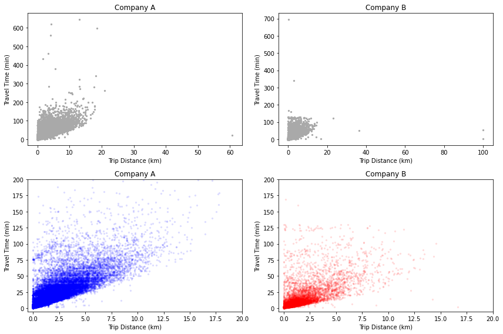

```python
plt.figure(figsize=(12,8))
plt.subplot(2,2,1)
plt.scatter(x=df_a.TripDistance,y=df_a.TravelTime,s=5,color="darkgray")
plt.title("Company A")
plt.xlabel("Trip Distance (km)")
plt.ylabel("Travel Time (min)")
plt.subplot(2,2,2)
plt.scatter(x=df_b.TripDistance,y=df_b.TravelTime,s=5,color="darkgray")
plt.title("Company B")
plt.xlabel("Trip Distance (km)")
plt.ylabel("Travel Time (min)")

xlims = [-0.5,20]
ylims = [-5,200]

plt.subplot(2,2,3)
plt.scatter(x=df_a.TripDistance,y=df_a.TravelTime,alpha=0.1,s=5,color="blue")
plt.xlim(xlims)
plt.ylim(ylims)
plt.title("Company A")
plt.xlabel("Trip Distance (km)")
plt.ylabel("Travel Time (min)")
plt.subplot(2,2,4)
plt.scatter(x=df_b.TripDistance,y=df_b.TravelTime,alpha=0.1,s=5,color="red")
plt.xlim(xlims)
plt.ylim(ylims)
plt.title("Company B")
plt.xlabel("Trip Distance (km)")
plt.ylabel("Travel Time (min)")
plt.tight_layout()
plt.show()
```

- In both companies, the overall travel time and trip distance data are distributed similar. (Positive correlation)
- Company A's users **ride scooter longer** and **travel much broader area** across the city.
- Later, We will check the coverage of scooter rides with city map.

## 2. Data Visualization - Mobility(Scooter) Usage Overview

- To estimate the number of scooter, we will aggregate log data according to the number of trips and unique scooters
- In this chapter, we will visualize trips count with multiple time dimension.
- We will deicide modeling frame work whether time series based forecast or regression based prediction

### Number of trips comparison

- Check the availability of time series model

Number of trips over datetime

```python
# Count number of trips across different time period
temp_a = df_a.groupby(by=['StartDate',]).count()['TripID'].reset_index()
temp_b = df_b.groupby(by=['StartDate',]).count()['TripID'].reset_index()
```

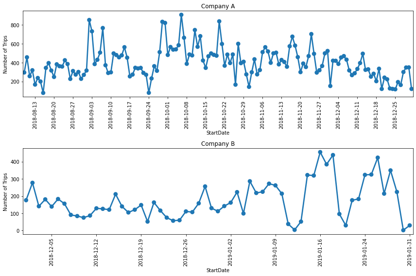

```python
plt.figure(figsize=(12,8))
plt.subplot(2,1,1)
ax1=sns.pointplot(x=temp_a.StartDate,y=temp_a.TripID,)
ax1.xaxis.set_major_locator(md.WeekdayLocator(byweekday = 0))
plt.xticks(rotation=90)
plt.ylabel("Number of Trips")
plt.title("Company A")

plt.subplot(2,1,2)
ax2=sns.pointplot(x=temp_b.StartDate,y=temp_b.TripID,)
ax2.xaxis.set_major_locator(md.WeekdayLocator(byweekday = 0))
plt.xticks(rotation=90)
plt.ylabel("Number of Trips")
plt.title("Company B")
plt.tight_layout()
plt.show()
```

- Both company's trip graph does not show particular time related pattern for time series analysis.
- We will see the average trip distance per day for various time dimension.

The average number of trips per day over month

```python
a = df_a.groupby(by=['StartDate','StartTime_month']).count()['TripID'].reset_index()
temp_a = a.groupby(by=['StartTime_month']).mean()['TripID'].reset_index()
b = df_b.groupby(by=['StartDate','StartTime_month']).count()['TripID'].reset_index()
temp_b = b.groupby(by=['StartTime_month']).mean()['TripID'].reset_index()
```

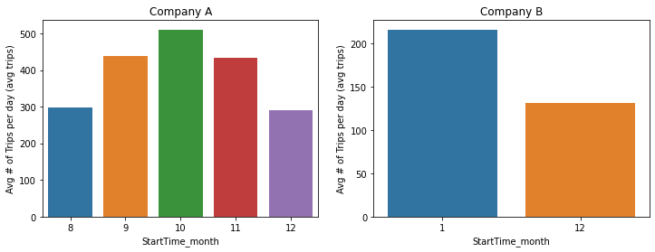

```python
# Total number of trips per day for each month
plt.figure(figsize=(12,4))
plt.subplot(1,2,1)
sns.barplot(x=temp_a.StartTime_month,y=temp_a.TripID,)
plt.ylabel("Avg # of Trips per day (avg trips)")
plt.title("Company A")
plt.subplot(1,2,2)
sns.barplot(x=temp_b.StartTime_month,y=temp_b.TripID,)
plt.ylabel("Avg # of Trips per day (avg trips)")
plt.title("Company B")
plt.show()
```

The average number of trips per day over month (weekday vs weekend)

```python
a = df_a.groupby(by=['StartDate','StartTime_month','StartTime_weekday']).count()['TripID'].reset_index()
temp_a = a.groupby(by=['StartTime_month','StartTime_weekday']).mean()['TripID'].reset_index()
b = df_b.groupby(by=['StartDate','StartTime_month','StartTime_weekday']).count()['TripID'].reset_index()
temp_b = b.groupby(by=['StartTime_month','StartTime_weekday']).mean()['TripID'].reset_index()
```

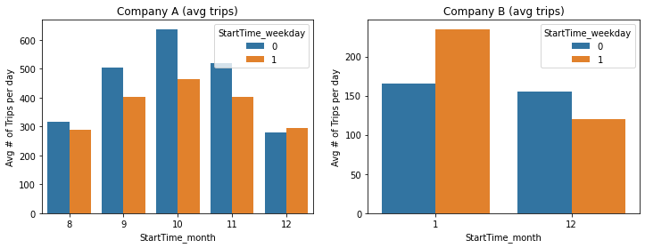

```python
# Total number of trips per day for each month
plt.figure(figsize=(12,4))
plt.subplot(1,2,1)
sns.barplot(x=temp_a.StartTime_month,y=temp_a.TripID,hue=temp_a.StartTime_weekday)
plt.ylabel("Avg # of Trips per day")
plt.title("Company A (avg trips)")
plt.subplot(1,2,2)
sns.barplot(x=temp_b.StartTime_month,y=temp_b.TripID,hue=temp_b.StartTime_weekday)
plt.ylabel("Avg # of Trips per day")
plt.title("Company B (avg trips)")
plt.show()
```

- Compared to company B, people ride more company A's scooter during the weekend.

The average number of trips per day during day (weekday vs weekend)

```python
a = df_a.groupby(by=['StartDate','StartTime_weekday','StartTime_hour']).count()['TripID'].reset_index()
temp_a = a.groupby(by=['StartTime_weekday','StartTime_hour']).mean()['TripID'].reset_index()
b = df_b.groupby(by=['StartDate','StartTime_weekday','StartTime_hour']).count()['TripID'].reset_index()
temp_b = b.groupby(by=['StartTime_weekday','StartTime_hour']).mean()['TripID'].reset_index()
```

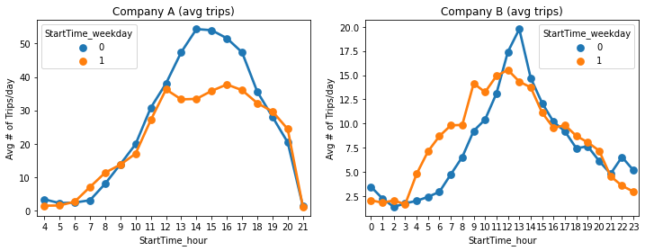

```python
# Average number of trips per day at weekday
plt.figure(figsize=(12,4))
plt.subplot(1,2,1)
sns.pointplot(x=temp_a.StartTime_hour,y=temp_a.TripID,hue=temp_a.StartTime_weekday,)
plt.ylabel("Avg # of Trips/day")
plt.title("Company A (avg trips)")
plt.subplot(1,2,2)
sns.pointplot(x=temp_b.StartTime_hour,y=temp_b.TripID,hue=temp_b.StartTime_weekday,)
plt.ylabel("Avg # of Trips/day")
plt.title("Company B (avg trips)")
plt.show()
```

Average number of trips per day for each month

```python
a = df_a.groupby(by=['StartDate','StartTime_month','StartTime_hour']).count()['TripID'].reset_index()
temp_a = a.groupby(by=['StartTime_month','StartTime_hour']).mean()['TripID'].reset_index()
b = df_b.groupby(by=['StartDate','StartTime_month','StartTime_hour']).count()['TripID'].reset_index()
temp_b = b.groupby(by=['StartTime_month','StartTime_hour']).mean()['TripID'].reset_index()
```

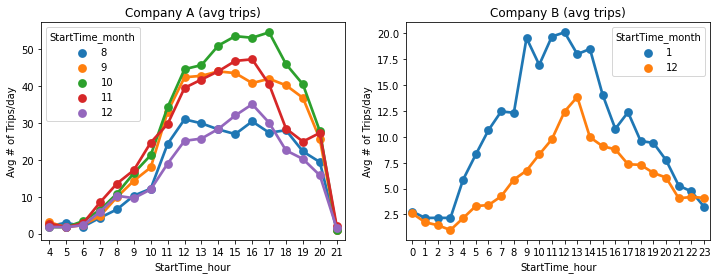

```python
# Compare the number of Trips for each company during the day
plt.figure(figsize=(12,4))
plt.subplot(1,2,1)

sns.pointplot(x=temp_a.StartTime_hour,y=temp_a.TripID,hue=temp_a.StartTime_month,)
plt.ylabel("Avg # of Trips/day")
plt.title("Company A (avg trips)")
plt.subplot(1,2,2)

sns.pointplot(x=temp_b.StartTime_hour,y=temp_b.TripID,hue=temp_b.StartTime_month,)
plt.ylabel("Avg # of Trips/day")
plt.title("Company B (avg trips)")
plt.show()
```

- Company A does **not provide** its mobility service **from 22 pm to 3 am**, while company B do operate
- In general, company B's the **peak time** of scooter rides is **earlier** than Company A (company A's peak=15-17, company B's peak=11-13)
- Time series analysis is not applicable to build the relation company A and company B because both company's ride pattern is different.

### Trip Distance and Travel Time comparison

Average Trip Distance difference

```python
# Count number of trips across different time period
temp_a = df_a.groupby(by=['StartTime_month','StartTime_weekday']).mean()['TripDistance'].reset_index()
temp_b = df_b.groupby(by=['StartTime_month','StartTime_weekday']).mean()['TripDistance'].reset_index()
```

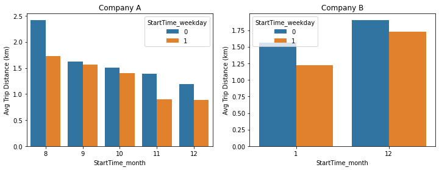

```python
# Total number of trips per day for each month
plt.figure(figsize=(12,4))
plt.subplot(1,2,1)
sns.barplot(x=temp_a.StartTime_month,y=temp_a.TripDistance,hue=temp_a.StartTime_weekday)
plt.ylabel("Avg Trip Distance (km)")
plt.title("Company A")
plt.subplot(1,2,2)
sns.barplot(x=temp_b.StartTime_month,y=temp_b.TripDistance,hue=temp_b.StartTime_weekday)
plt.ylabel("Avg Trip Distance (km)")
plt.title("Company B")
plt.show()
```

```python
# Count number of trips across different time period
temp_a = df_a.groupby(by=['StartTime_month','StartTime_weekday']).mean()['TravelTime'].reset_index()
temp_b = df_b.groupby(by=['StartTime_month','StartTime_weekday']).mean()['TravelTime'].reset_index()
```

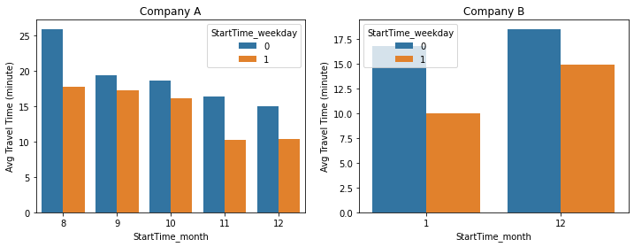

```python
# Total number of trips per day for each month
plt.figure(figsize=(12,4))
plt.subplot(1,2,1)
sns.barplot(x=temp_a.StartTime_month,y=temp_a.TravelTime,hue=temp_a.StartTime_weekday)
plt.ylabel("Avg Travel Time (minute)")
plt.title("Company A")
plt.subplot(1,2,2)
sns.barplot(x=temp_b.StartTime_month,y=temp_b.TravelTime,hue=temp_b.StartTime_weekday)
plt.ylabel("Avg Travel Time (minute)")
plt.title("Company B")
plt.show()
```

### Mapping the geographic information

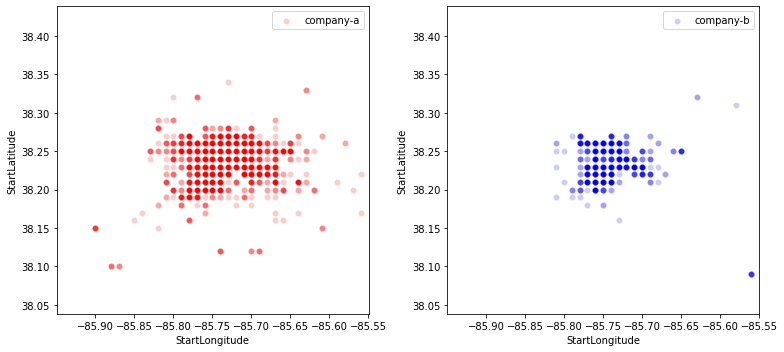

```python
# observe each datas
# map starting point's latitude and longitude
center_lat=(df_a.StartLatitude.mean()+df_b.StartLatitude.mean())/2
center_long=(df_a.StartLongitude.mean()+df_b.StartLongitude.mean())/2
ylims=[center_lat-0.2,center_lat+0.2]
xlims=[center_long-0.2,center_long+0.2]
plt.figure(figsize=(11,5))
plt.subplot(1,2,1)
sns.scatterplot(x="StartLongitude",y="StartLatitude",data=df_a,color="red",\
                label="company-a",alpha=0.2,)
plt.xlim(xlims)
plt.ylim(ylims)
plt.subplot(1,2,2)
sns.scatterplot(x="StartLongitude",y="StartLatitude",data=df_b,color="blue",\
                label="company-b",alpha=0.2,)
plt.xlim(xlims)
plt.ylim(ylims)
plt.legend()
plt.tight_layout()
plt.show()
```

Heatmap of departure points in Louisville

```python
import folium
from folium import Figure
from folium.plugins import HeatMap

print("Heatmap - Company A Start location at Louisville")
f = Figure(width=400, height=300, title="Company A Start location at Louisville")
map_a = folium.Map(location=[center_lat, center_long], zoom_start=10, tiles='cartodbpositron')
lat = df_a.StartLatitude.tolist()
lng = df_a.StartLongitude.tolist()
HeatMap(list(zip(lat, lng)),radius=10).add_to(map_a)
f.add_child(map_a)
f
```

```
Heatmap - Company A Start location at Louisville
```

[interactive chart not shown]

```python
print("Heatmap - Company B Start location at Louisville")
f = Figure(width=400, height=300, title="Company B Start location at Louisville")
map_b = folium.Map(location=[center_lat, center_long], zoom_start=10, tiles='cartodbpositron')
lat = df_b.StartLatitude.tolist()
lng = df_b.StartLongitude.tolist()
HeatMap(list(zip(lat, lng)),radius=10).add_to(map_b)
f.add_child(map_b)
f
```

```
Heatmap - Company B Start location at Louisville
```

[interactive chart not shown]

```python
# center coordinate of rides for each company
company_a_center = np.round([df_a.StartLatitude.median(),df_a.StartLongitude.median()],2)
company_b_center = np.round([df_b.StartLatitude.median(),df_b.StartLongitude.median()],2)
print("Company A mostly operates near Louisville Downtown, coordinates ",company_a_center)
print("Company B mostly operates near Old Louisville, coordinates : ",company_b_center)
```

```
Company A mostly operates near Louisville Downtown, coordinates  [ 38.25 -85.75]
Company B mostly operates near Old Louisville, coordinates :  [ 38.23 -85.76]
```

- Clearly, Company A operates in **larger area** than company B.
- Company A's primary operating region is Louisville Downtown and company B is on Old Louisville
- We can derive another feature which counts the unique location(coordinate) for each day.

## 3. Feature Generation for prediction model

### Feature generation

- We will aggregate log data for each date and we assume that each observation is independent.
- In this model, we use **number of trips for each day** and and normalized scaled features, such as **average distance and average time per day**.
- Also, we will create the area of operation for each company by counting the unique coordinate set. (future work: covert the coverage into neighborhood or Zoox own defined regional space)
- In this analysis, the unique number of scooter will be target variable to estimate.

```python
# Create coordinates elements for coverage feature
# Assumption : if the users behave in larger area, more scooter would be used for riding.
coord_a = list(zip(df_a.StartLatitude,df_a.StartLongitude))
coord_b = list(zip(df_b.StartLatitude,df_b.StartLongitude))
df_a_f = df_a.copy()
df_b_f = df_b.copy()
df_a_f['coord'] = coord_a
df_b_f['coord'] = coord_b
```

```python
# create features by aggregating the given dataset for each day
df_modeling_train = df_a_f.groupby(by=['StartDate']).agg(
    # count the total trip counts for each day
    Trip_count=pd.NamedAgg(column="TripID", aggfunc="count"),
    # count the unique scooter number in marketplace for each day
    Scooter_uniquecount=pd.NamedAgg(column="ScooterID", aggfunc="nunique"),
    # get the average trip distance  for each day
    Avg_distance=pd.NamedAgg(column="TripDistance", aggfunc="mean"),
    # get the average travel time for each day
    Avg_time=pd.NamedAgg(column="TravelTime", aggfunc="mean"),
    # count the unique coordinate for each day
    Coverage=pd.NamedAgg(column="coord",aggfunc="nunique")
).reset_index()
df_modeling_test = df_b_f.groupby(by=['StartDate']).agg(
    Trip_count=pd.NamedAgg(column="TripID", aggfunc="count"),
#     Scooter_uniquecount=pd.NamedAgg(column="ScooterID", aggfunc="nunique"),
    Avg_distance=pd.NamedAgg(column="TripDistance", aggfunc="mean"),
    Avg_time=pd.NamedAgg(column="TravelTime", aggfunc="mean"),
    Coverage=pd.NamedAgg(column="coord",aggfunc="nunique")
).reset_index()
```

### Explore the features with target variable(the unique scooter count)

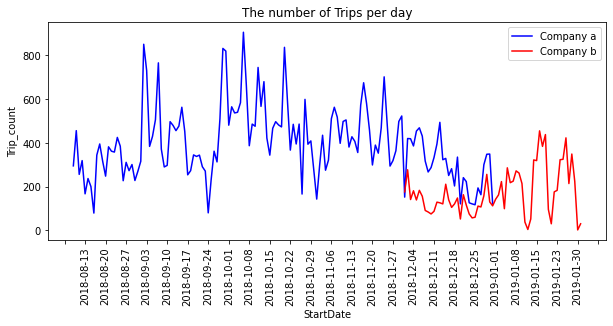

```python
fig,ax = plt.subplots(figsize=(10,4))
ax1=sns.lineplot(x="StartDate",y="Trip_count",data=df_modeling_train,color="blue",label="Company a")
sns.lineplot(x="StartDate",y="Trip_count",data=df_modeling_test,color="red",label="Company b")
ax1.xaxis.set_major_locator(md.WeekdayLocator(byweekday = 0))
plt.xticks(rotation=90)
plt.title("The number of Trips per day")
plt.show()
```

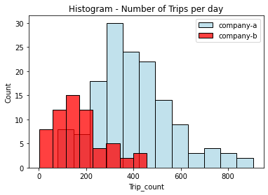

```python
sns.histplot(x="Trip_count",data=df_modeling_train,color="lightblue",bins="auto",label="company-a")
sns.histplot(x="Trip_count",data=df_modeling_test,color="red",bins="auto",label="company-b")
plt.title("Histogram - Number of Trips per day")
plt.legend()
plt.show()
```

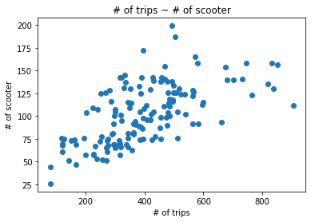

```python
# scatter plot (feature-target variable)
plt.scatter(df_modeling_train.Trip_count, df_modeling_train.Scooter_uniquecount)
plt.title("# of trips ~ # of scooter")
plt.xlabel("# of trips")
plt.ylabel("# of scooter")
plt.show()
```

Average of Trip Distance over time

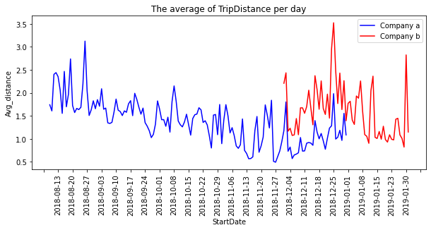

```python
fig,ax = plt.subplots(figsize=(10,4))
ax1=sns.lineplot(x="StartDate",y="Avg_distance",data=df_modeling_train,color="blue",label="Company a")
sns.lineplot(x="StartDate",y="Avg_distance",data=df_modeling_test,color="red",label="Company b")
ax1.xaxis.set_major_locator(md.WeekdayLocator(byweekday = 0))
plt.xticks(rotation=90)
plt.title("The average of TripDistance per day")
plt.show()
```

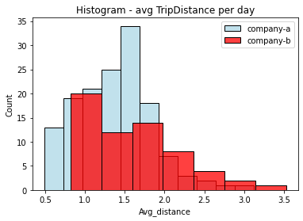

```python
sns.histplot(x="Avg_distance",data=df_modeling_train,color="lightblue",bins="auto",label="company-a")
sns.histplot(x="Avg_distance",data=df_modeling_test,color="red",bins="auto",label="company-b")
plt.title("Histogram - avg TripDistance per day")
plt.legend()
plt.show()
```

Average distance data is right skewed, so we will apply log and standardization

```python
df_modeling_train['log_avg_distance']=np.log(df_modeling_train.Avg_distance)
df_modeling_test['log_avg_distance']=np.log(df_modeling_test.Avg_distance)
```

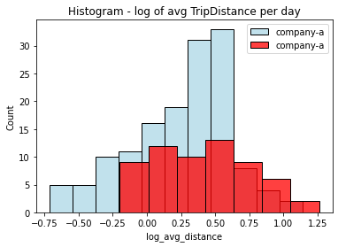

```python
sns.histplot(x="log_avg_distance",data=df_modeling_train,color="lightblue",bins="auto",label="company-a")
sns.histplot(x="log_avg_distance",data=df_modeling_test,color="red",bins="auto",label="company-a")
plt.title("Histogram - log of avg TripDistance per day")
plt.legend()
plt.show()
```

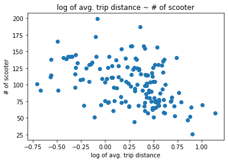

```python
plt.scatter(df_modeling_train.log_avg_distance, df_modeling_train.Scooter_uniquecount)
plt.title("log of avg. trip distance ~ # of scooter")
plt.xlabel("log of avg. trip distance")
plt.ylabel("# of scooter")
plt.show()
```

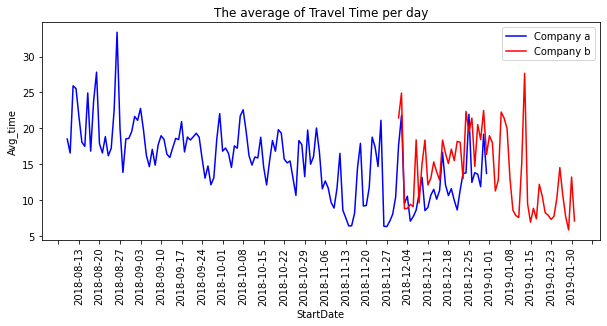

```python
fig,ax = plt.subplots(figsize=(10,4))
ax1=sns.lineplot(x="StartDate",y="Avg_time",data=df_modeling_train,color="blue",label="Company a")
sns.lineplot(x="StartDate",y="Avg_time",data=df_modeling_test,color="red",label="Company b")
ax1.xaxis.set_major_locator(md.WeekdayLocator(byweekday = 0))
plt.xticks(rotation=90)
plt.title("The average of Travel Time per day")
plt.show()
```

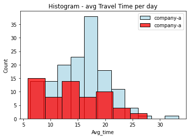

```python
sns.histplot(x="Avg_time",data=df_modeling_train,color="lightblue",bins="auto",label="company-a")
sns.histplot(x="Avg_time",data=df_modeling_test,color="red",bins="auto",label="company-a")
plt.title("Histogram - avg Travel Time per day")
plt.legend()
plt.show()
```

Average Travel Time data is right skewed, so we will apply log and standardization

```python
df_modeling_train['log_avg_time']=np.log(df_modeling_train.Avg_time)
df_modeling_test['log_avg_time']=np.log(df_modeling_test.Avg_time)
```

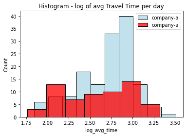

```python
sns.histplot(x="log_avg_time",data=df_modeling_train,color="lightblue",bins="auto",label="company-a")
sns.histplot(x="log_avg_time",data=df_modeling_test,color="red",bins="auto",label="company-a")
plt.title("Histogram - log of avg Travel Time per day")
plt.legend()
plt.show()
```

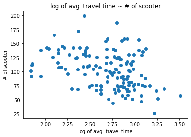

```python
plt.scatter(df_modeling_train.log_avg_time, df_modeling_train.Scooter_uniquecount)
plt.title("log of avg. travel time ~ # of scooter")
plt.xlabel("log of avg. travel time")
plt.ylabel("# of scooter")
plt.show()
```

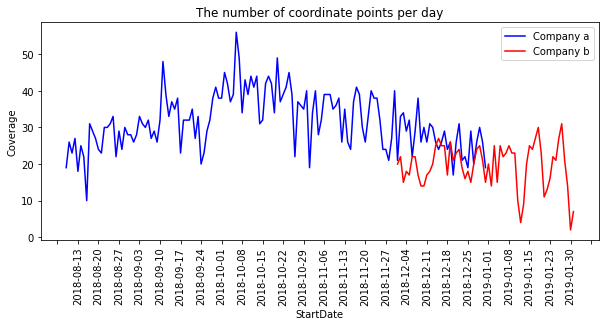

```python
fig,ax = plt.subplots(figsize=(10,4))
ax1=sns.lineplot(x="StartDate",y="Coverage",data=df_modeling_train,color="blue",label="Company a")
sns.lineplot(x="StartDate",y="Coverage",data=df_modeling_test,color="red",label="Company b")
ax1.xaxis.set_major_locator(md.WeekdayLocator(byweekday = 0))
plt.xticks(rotation=90)
plt.title("The number of coordinate points per day")
plt.show()
```

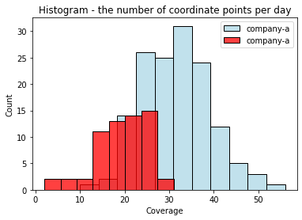

```python
sns.histplot(x="Coverage",data=df_modeling_train,color="lightblue",bins="auto",label="company-a")
sns.histplot(x="Coverage",data=df_modeling_test,color="red",bins="auto",label="company-a")
plt.title("Histogram - the number of coordinate points per day")
plt.legend()
plt.show()
```

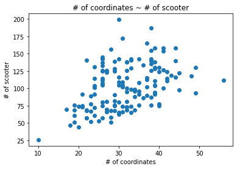

```python
plt.scatter(df_modeling_train.Coverage, df_modeling_train.Scooter_uniquecount)
plt.title("# of coordinates ~ # of scooter")
plt.xlabel("# of coordinates")
plt.ylabel("# of scooter")
plt.show()
```

## 4. Modeling (Estimate company B's the number of scooters)

- Using features we generated, we will train the simple model.
- As we see above, there is noticeable no time-dependent trend and only few features are available, so we will use OLS(linear regression) model to predict the number of scooters for each day.
- If we can add or generate more features, we could build ensemble model, such random-forest or XG-boost.

```python
# correlation matrix
cols = ['Trip_count','log_avg_distance','log_avg_time','Coverage']
target = ['Scooter_uniquecount']
df_modeling = df_modeling_train[cols+target]
corr = df_modeling.corr()
corr.style.background_gradient(cmap='coolwarm')
```

|  | Trip_count | log_avg_distance | log_avg_time | Coverage | Scooter_uniquecount |
| --- | --- | --- | --- | --- | --- |
| Trip_count | 1.000000 | 0.008401 | 0.071406 | 0.736124 | 0.625147 |
| log_avg_distance | 0.008401 | 1.000000 | 0.965805 | 0.081721 | -0.416628 |
| log_avg_time | 0.071406 | 0.965805 | 1.000000 | 0.130849 | -0.364382 |
| Coverage | 0.736124 | 0.081721 | 0.130849 | 1.000000 | 0.452250 |
| Scooter_uniquecount | 0.625147 | -0.416628 | -0.364382 | 0.452250 | 1.000000 |

- As we expected, avg distance and avg time are highly related(correlation:0.97), so we will use **avg_distance only.**
- The number of coordinates per day can affect the number of scooter operation per day because the bigger coverage user moves, the more scooter we need.

```
Scatter plot - X features vs. y
```

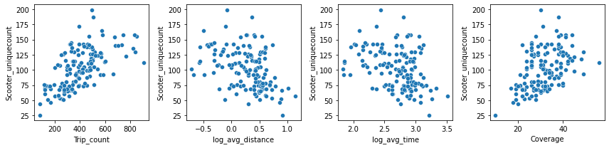

```python
print("Scatter plot - X features vs. y")
plt.figure(figsize=(12,3))
for i in range(len(cols)):
    plt.subplot(1,len(cols),i+1)
    sns.scatterplot(x=cols[i],y='Scooter_uniquecount',data=df_modeling_train)
plt.tight_layout()
plt.show()
```

```python
cols = ['Trip_count','log_avg_distance','Coverage']
X_train = df_modeling_train[cols]
X_test = df_modeling_test[cols]
y_train = df_modeling_train['Scooter_uniquecount']
```

```python
# feature scaling
from sklearn.preprocessing import StandardScaler
scaler = StandardScaler()
X_train_scaled=scaler.fit_transform(X_train)
X_test_scaled=scaler.transform(X_test)
```

```python
# !pip install statsmodels
import statsmodels.api as sm
y = y_train
X = sm.add_constant(X_train_scaled)
lmodel = sm.OLS(y,X)
results = lmodel.fit()
results.summary()
```

OLS Regression Results

| Dep. Variable: | Scooter_uniquecount | R-squared: | 0.570 |
| --- | --- | --- | --- |
| Model: | OLS | Adj. R-squared: | 0.561 |
| Method: | Least Squares | F-statistic: | 61.88 |
| Date: | Fri, 27 May 2022 | Prob (F-statistic): | 1.57e-25 |
| Time: | 09:44:44 | Log-Likelihood: | -644.01 |
| No. Observations: | 144 | AIC: | 1296. |
| Df Residuals: | 140 | BIC: | 1308. |
| Df Model: | 3 |  |  |
| Covariance Type: | nonrobust |  |  |

|  | coef | std err | t | P>\|t\| | [0.025 | 0.975] |
| --- | --- | --- | --- | --- | --- | --- |
| const | 102.4792 | 1.791 | 57.234 | 0.000 | 98.939 | 106.019 |
| x1 | 19.0564 | 2.653 | 7.182 | 0.000 | 13.811 | 24.302 |
| x2 | -13.7614 | 1.802 | -7.637 | 0.000 | -17.324 | -10.199 |
| x3 | 1.7094 | 2.662 | 0.642 | 0.522 | -3.554 | 6.972 |

| Omnibus: | 19.101 | Durbin-Watson: | 0.971 |
| --- | --- | --- | --- |
| Prob(Omnibus): | 0.000 | Jarque-Bera (JB): | 25.507 |
| Skew: | 0.756 | Prob(JB): | 2.89e-06 |
| Kurtosis: | 4.402 | Cond. No. | 2.59 |

Notes:  
[1] Standard Errors assume that the covariance matrix of the errors is correctly specified.

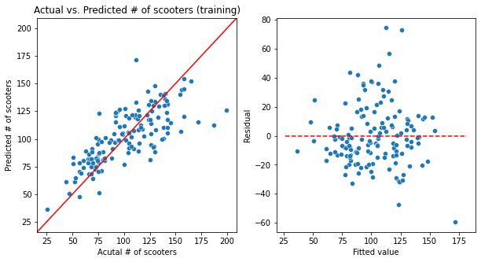

```python
# draw actual vs. predicted
y_pred=results.predict()
residuals = y-y_pred
lines=[min(min(y),min(y_pred))-10,max(max(y),max(y_pred))+10]
plt.figure(figsize=(10,5))
plt.subplot(1,2,1)
sns.scatterplot(x=y,y=y_pred)
plt.plot(lines,lines,color='r')
plt.title("Actual vs. Predicted # of scooters (training)")
plt.xlabel("Acutal # of scooters")
plt.ylabel("Predicted # of scooters")
plt.xlim(min(min(y),min(y_pred))-10,max(max(y),max(y_pred))+10)
plt.ylim(min(min(y),min(y_pred))-10,max(max(y),max(y_pred))+10)
# check heteroscedasticity
plt.subplot(1,2,2)
sns.scatterplot(x=y_pred,y=residuals)
lines=[min(y_pred)-10,max(y_pred)+10]
plt.plot(lines,[0,0],color='r',linestyle='dashed')
plt.xlabel("Fitted value")
plt.ylabel("Residual")
plt.title("")
plt.show()
```

```python
# check the OLS's prediction vs actual value
print("Actual the number of scooter per day over time: ",sum(y))
print("Predicted the number of scooter per day over time: ",sum(y_pred))
```

```
Actual the number of scooter per day over time:  14757
Predicted the number of scooter per day over time:  14756.999999999996
```

```python
# predict company B's the number of scooters for each day
X_t = sm.add_constant(X_test_scaled)
y_test_pred=results.predict(X_t)
y_test_pred
```

```
array([ 54.16273226,  62.73387056,  72.67405368,  76.03796699,
        75.98234943,  81.77628512,  68.14325275,  69.85507012,
        52.39947395,  51.36247305,  56.14365025,  57.91294215,
        50.95960613,  59.17164707,  79.3435806 ,  48.40419124,
        49.33508413,  58.05268203,  51.380833  ,  50.54486696,
        66.93990213,  52.27226196,  57.79774327,  28.56475504,
        22.81928717,  41.17982543,  54.39943299,  49.39277179,
        75.72339768,  48.08772486,  62.70067285,  58.35056641,
        58.4555626 ,  77.52226   ,  63.38550689,  73.07079557,
        65.40269833,  59.69920832,  78.49626583,  90.98872217,
        86.68958489,  69.09155248,  33.36599464,  34.74484682,
        99.42032989, 101.08951326, 111.50323551, 109.69428039,
       107.36139624,  75.55227974,  67.29738951,  78.89508336,
        83.90879612, 102.04069009,  88.00109157, 100.21879203,
        87.42408002, 103.66798814,  95.21338723,  20.71548525,
        58.55281488])
```

### Conclusion

Now, we can estimate **the number of scooter** for company B for each day given corresponding information, such as total trips per day, average trip distance, and coverage.  
The number of total trips per day and scooter moving coverage has positive relation with the number of scooter, but trip distance has negative one.

In this report, we assume that company'A and B has similar user environment because they operate within almost similar region(near Downtown Louisville).  
However, to estimate the number total scooter to deploy for their business, we need to consider the availability of mobility(scooter) and business strategy to provide sufficient supply to enable more users can ride their mobility service.